# Homework2

Luis Noguera

4/19/2020

## Initial Set Up

```r
# Importing libraries and set up the work environment
library(knitr)
library(readxl)
library(tidyverse)
library(dplyr)
library(tidymodels)
library(janitor)
library(plotly)
library(rpart)
library(readr)
library(tidymodels)
library(gbm)

knitr::opts_chunk$set(cache = TRUE,
                      warning = FALSE,
                      echo = TRUE,
                      message = FALSE,
                      dpi = 180,
                      fig.width = 6,
                      fig.height = 4)


theme_set(theme_classic())
```

# Problem 1

**Advantages**

Selecting random variables from the bootstrap prevents the model from choosing variables that are highly correlated with each other. Selecting random variables as a stratey generated variation among the tree which prevents splits on the same variables. This approach makes random forest models, great to prevent overfitting on the training set.

**Disadvantages**

Random Forest does not offer the benefit of explainability on each variable like linear models or regularization models do. It conveys information about how important or unimportant a variable is but does not show how this affects the classification or regression problem. Furthermore, adding insignficant variables to a random forest model will force the statistical model to split the data on nodes that are useless for the problem at hand.

One can introduce additional tree variation in the forest by increasing or limiting the minimum number of data points in a node that are required for the node to split further.

# Problem 2

Regularization in linear models with many features is crucial since not all the variables help explain the variance in the response; in fact most of them would introduce noise into the model that would cause the linear model to overfit on the training data causing future predictions to perform poorly. However, this simplification of coefficients putting an infinite weigh on the regularization can be as harmful to the model as it can be good; the reason is because it can be severely bias to those features that help explain the variance in the first place, making future predictions useless if those coefficients are brought down to 0. This is why important to make a range of lambda options, an iterate many times to evaluate what is the best weight for regularization.

Sparsity in the boosting context would not be a reasonable approach when the number of predictors/base learner fucntion is small, specially when all the the predictors are effective on explaining the response. In reality, this rarely happens; in fact, all predictors could add very little to the explainability of the response, which the researcher or analyst in this case would prefer to reduce the coefficients to those that better help predict the outcome.

# Problem 3

# Problem 4

# Problem 5

# Problem 6

# 6.0 Data Import

```r
spam_train <- read_csv("spam_stats315B_train.csv",
    col_names = FALSE)

spam_test <- read_csv("spam_stats315B_test.csv",
    col_names = FALSE)

header_spam<-c("make", "address", "all", "3d", "our", "over", "remove","internet","order", "mail", "receive", "will","people", "report", "addresses","free", "business","email", "you", "credit", "your", "font","000","money","hp", "hpl", "george", "650", "lab", "labs","telnet", "857", "data", "415", "85", "technology", "1999","parts","pm", "direct", "cs", "meeting", "original", "project","re","edu", "table", "conference", ";", "(", "[", "!", "$", "#","CAPAVE", "CAPMAX", "CAPTOT","type")

colnames(spam_train) <- header_spam
colnames(spam_test) <- header_spam

# Checking if there is class imbalance in the response.
spam_train %>%
  count(type)
```

```
## # A tibble: 2 x 2
##    type     n
##   <dbl> <int>
## 1     0  1849
## 2     1  1218
```

# 6.1 Building the GBM model - Email Spam

```r
set.seed(415)
gbm.spam <- gbm(type~.,
                data = spam_train,
                interaction.depth =  4,
                shrinkage = 0.5,
                cv.folds = 5,
                distribution = 'bernoulli',
                verbose = T)
```

# Evaluating the GBM fit.

```r
gbm.spam.predict <- predict(gbm.spam,
                            spam_test,
                            type = 'response',
                            n.trees = 100) %>%
  as.data.frame()

# Personal Note - Accordiing to the gbm tutorial, the threshhold is set by the user. In this case I chose 0.5
gbm.spam.outcome <- gbm.spam.predict %>%
  mutate(predicted = as.numeric(gbm.spam.predict >= 0.5)) %>%
  bind_cols(spam_test) %>%
  select(predicted, type)

# Confusion Matrix
confusion_matrix <- table(gbm.spam.outcome)
confusion_matrix
```

```
##          type
## predicted   0   1
##         0 887  23
##         1  29 595
```

```r
# Accuracy per class
diag(prop.table(confusion_matrix,1))
```

```
##         0         1
## 0.9747253 0.9535256
```

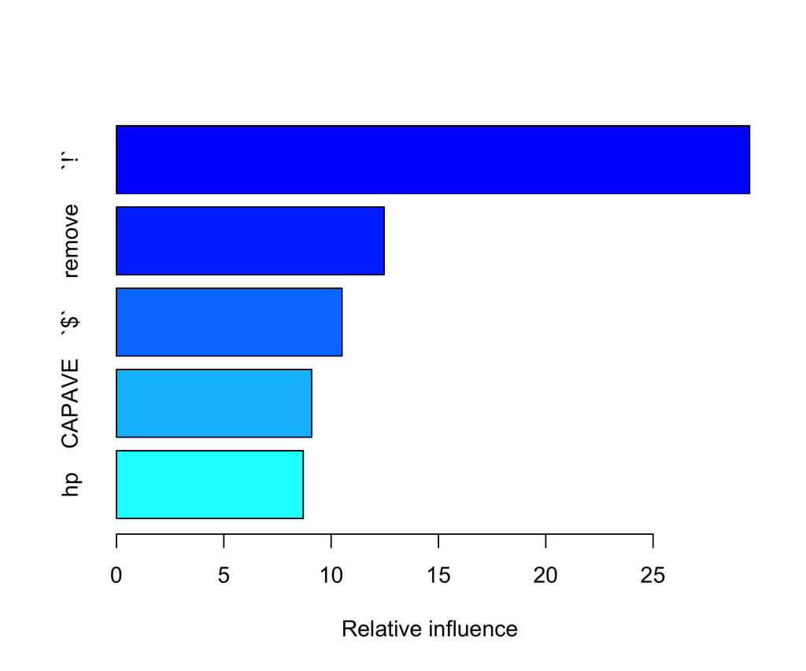

```
##                   var      rel.inf
## `!`               `!` 29.494696079
## remove         remove 12.471280998
## `$`               `$` 10.507146248
## CAPAVE         CAPAVE  9.092340209
## hp                 hp  8.701026639
## free             free  5.192860039
## your             your  3.939508631
## our               our  3.048048171
## CAPMAX         CAPMAX  2.306830090
## CAPTOT         CAPTOT  1.715448008
## edu               edu  1.574517739
## `000`           `000`  1.009529866
## money           money  0.983405495
## receive       receive  0.887349614
## re                 re  0.849672043
## you               you  0.826996063
## email           email  0.754844970
## will             will  0.731118888
## george         george  0.647565490
## `650`           `650`  0.646955068
## internet     internet  0.479338132
## mail             mail  0.454322645
## `;`               `;`  0.425687898
## `(`               `(`  0.379534837
## all               all  0.325645516
## meeting       meeting  0.303922095
## business     business  0.280077015
## `1999`         `1999`  0.257164020
## `3d`             `3d`  0.254162055
## order           order  0.247536713
## report         report  0.243747937
## technology technology  0.194444799
## over             over  0.160020075
## data             data  0.117457546
## lab               lab  0.104160437
## labs             labs  0.102136282
## `[`               `[`  0.081378833
## address       address  0.065998670
## project       project  0.046597066
## make             make  0.039538050
## conference conference  0.020465852
## `85`             `85`  0.011501072
## `#`               `#`  0.008727062
## font             font  0.007980032
## hpl               hpl  0.007315013
## people         people  0.000000000
## addresses   addresses  0.000000000
## credit         credit  0.000000000
## telnet         telnet  0.000000000
## `857`           `857`  0.000000000
## `415`           `415`  0.000000000
## parts           parts  0.000000000
## pm                 pm  0.000000000
## direct         direct  0.000000000
## cs                 cs  0.000000000
## original     original  0.000000000
## table           table  0.000000000
```

```r
# Most important words to classifcy the spam from non-spam emails
summary(gbm.spam,5)
```

The model did a pretty good job at predicting both classes! It achieved a misclassification error of 2.5% for non-spam email and 4% for spam emails.

## 6.2 Building the Weighted Spam Model

**(b) Your classifier in part (a) can be used as a spam filter. One of the possible disadvantagesof such a spam filter is that it might filter out too many good (non-spam) emails. Therefore, abetter spam filter might be the one that penalizes misclassifying non-spam emails more heavilythan the spam ones. Suppose that you want to build a spam filterthat “throws out” no morethat 0.3% of the good (non-spam) emails. You have to find and use a cost matrix that penalizesmisclassifying “good” emails as“spam” more than misclassifying “spam” emails as “good” by themethod of trial and error. Once you have constructed your final spam filter with the propertydescribed above, answer the following questions:**

```r
set.seed(415)
weights <- ifelse(spam_train$type == 0, 100, 3)


gbm.spam.weight <- gbm(type ~.,
                           data = spam_train,
                           weights = weights,
                           shrinkage = 0.05,
                           cv.folds = 5,
                           distribution = 'bernoulli',
                           verbose = FALSE
)


gbm.weight.test <- predict(gbm.spam.weight, spam_test, type = 'response') %>% as.data.frame()
```

```
## Using 100 trees...
```

```r
gbm.weight.pred <- gbm.weight.test %>%
  mutate(predicted = as.numeric(gbm.weight.test >= 0.5)) %>%
  bind_cols(spam_test) %>%
  select(predicted, type)

confusion_matrix_weight <- table(gbm.weight.pred)
confusion_matrix_weight
```

```
##          type
## predicted   0   1
##         0 915 367
##         1   1 251
```

*(i) What is the overall misclassification error of your final filter and what is the percentage of good emails and spam emails that were misclassified respectively?*

**Here the overall missclassification rate.**

```r
# Overall missclasification error
attach(gbm.weight.pred)
weight.missclasification <- scales::percent(mean(predicted != type))
weight.missclasification
```

```
## [1] "24%"
```

**Here the accuracy per class**

```r
# Accuracy per class
accuracy.pre.class <- diag(prop.table(confusion_matrix_weight,1)) %>% tibble::enframe(name=NULL)
accuracy.pre.class
```

```
## # A tibble: 2 x 1
##   value
##   <dbl>
## 1 0.714
## 2 0.996
```

```r
negative.class.error <- accuracy.pre.class %>%
  mutate(class.error = (1 - value)*100) %>% select(class.error) %>% head(1)
negative.class.error
```

```
## # A tibble: 1 x 1
##   class.error
##         <dbl>
## 1        28.6
```

```r
positive.class.error <- accuracy.pre.class %>%
  mutate(class.error = (1 - value)*100) %>% select(class.error) %>% tail(1)
positive.class.error
```

```
## # A tibble: 1 x 1
##   class.error
##         <dbl>
## 1       0.397
```

*(ii) What are the important variables in discriminating good emails from spam for your spam filter?*

**Most Important Variables for the Spam Email Model**

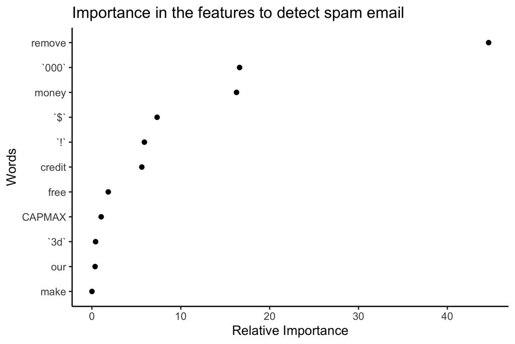

```r
important.words.df %>%
  head(11) %>%
  mutate(var = fct_reorder(var, rel.inf)) %>%
  ggplot(aes(rel.inf, var)) +
  geom_point() +
  labs(title = 'Importance in the features to detect spam email',
       y = 'Words',
       x = 'Relative Importance')
```

*(iii) Using the interpreting tools provided by gbm, describe the dependence of the response on the most important attributes.*

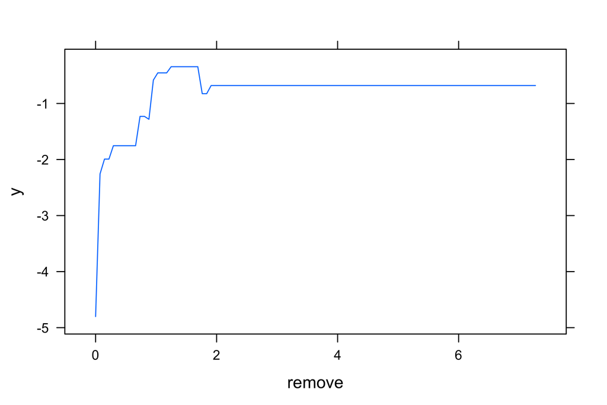

```r
# Variable remove
plot(gbm.spam.weight, i.var = 7)
```

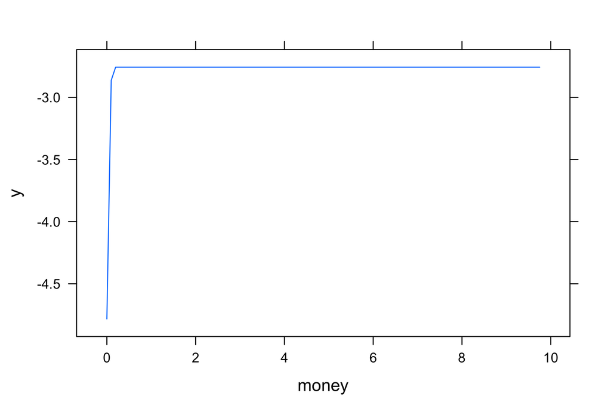

```r
# Variable Money
plot(gbm.spam.weight, i.var = 24)
```

The words remove, numbers 000 and the word money. Represent the most important features when modelling for spam and ham emails. In the first model, the features that better helped predict the classification where associated with the frequency of exclamation points and dollar signs. Interesting and meaningful learnings!

# Problem 7

## 7.0 Data Import

```r
calif_housing <- read_csv("calif_stats315B.csv")

head(calif_housing)
```

```
## # A tibble: 6 x 9
##   median_h_value median_income h_median_age avg_rooms avg_bedrooms population
##            <dbl>         <dbl>        <dbl>     <dbl>        <dbl>      <dbl>
## 1           4.53          8.33           41      6.98        1.02         322
## 2           3.58          8.30           21      6.24        0.972       2401
## 3           3.52          7.26           52      8.29        1.07         496
## 4           3.41          5.64           52      5.82        1.07         558
## 5           3.42          3.85           52      6.28        1.08         565
## 6           2.70          4.04           52      4.76        1.10         413
## # … with 3 more variables: avg_occupancy <dbl>, latitude <dbl>, longitude <dbl>
```

# 7.1 Data Split

```r
calif_housing_split <- initial_split(calif_housing)

housing_training <- training(calif_housing_split)
housing_testing <- testing(calif_housing_split)
```

# 7.2 Some Exploration

Exploring the house value based on the location data provided

Just by looking at the locations of the counties in this map, we can see the areas where the median house value is more expensive than others. Most expensive median house values are cluttered together to what it seems to be near the coast of SF. Also, an important aspact to highlight from this visualization is that there are some areas with a very high median house value visualized in red here, some many others in orange and a few low median house value scatter around

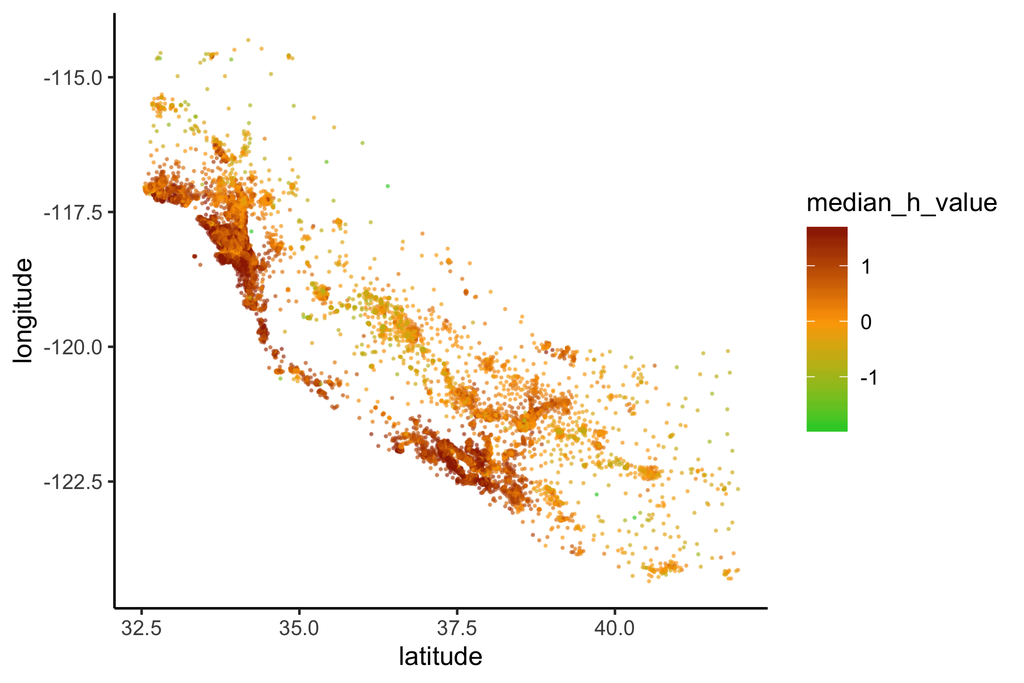

```r
calif_housing %>%
  mutate(median_h_value = log(median_h_value)) %>% # Using the log of median house value to plot it
  ggplot(aes(latitude, longitude, color = median_h_value)) +
  geom_point(size = 0.2, alpha = 0.5) +
  scale_color_gradient2(low = 'limegreen', mid = 'orange', high = 'dark red')
```

## 7.3 Building the GBM Model for the Housing Dataset.

```r
gbm.housing <- gbm(median_h_value~.,
                   data=housing_training,
                   interaction.depth = 6,
                   n.trees = 2000,
                   cv.folds = 3,
                   distribution = 'gaussian',
                   verbose = F
                   )
```

## 7.4 Feature Importance

```r
set.seed(415)
housing.pred <- predict(gbm.housing, housing_testing) %>%
  as.data.frame()
```

```
## Using 1985 trees...
```

```r
true.pred.df <- housing_testing %>%
  select(median_h_value) %>%
  bind_cols(housing.pred) %>%
  rename('pred' = '.')

# Number of trees used
best_iter <- gbm.perf(gbm.housing, method = 'cv')
```

[figure not shown]

```r
MSE <- sum((true.pred.df$pred - true.pred.df$median_h_value)^2)


MSE
```

```
## [1] 1101.181
```

**(a) The prediction accuracy of gbm on the data set.**

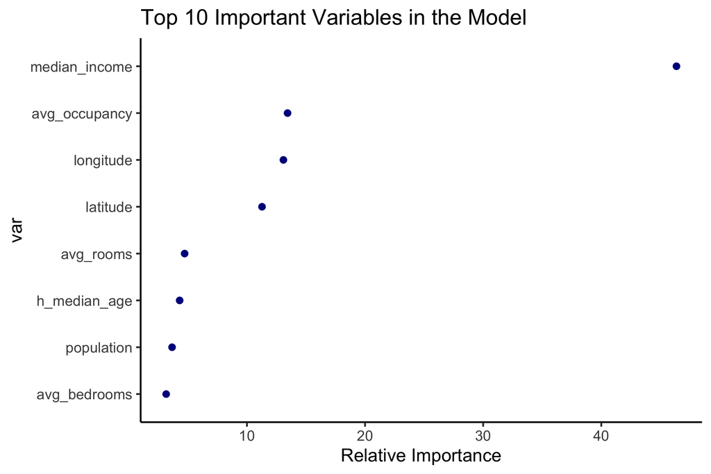

```r
importance_housing %>%
  mutate(var = fct_reorder(var, rel.inf)) %>%
  head(10) %>%
  ggplot(aes(var, rel.inf)) +
  geom_point(color = 'dark blue') +
  coord_flip() +
  labs(title = 'Top 10 Important Variables in the Model',
       y = "Relative Importance")
```

**(b) Identification of the most important variables.**

The most important features for the model are:

- Median Income
- Occupancy
- Location (Lantitud and Longitude)